# Task04_Example_Run_ModelG.Rmd

Andy Stein

01 August, 2018

```r
# This code may be needed if run on Windows
Sys.setenv(PATH = paste(Sys.getenv("PATH"), "C:/RBuildTools/3.4/bin/", "C:/RBuildTools/3.4/mingw_64/bin", sep = ";"))
Sys.setenv(BINPREF = "C:/RBuildTools/3.4/mingw_64/bin/")

# To be called at the top of every Rmd file. Initialization code and some useful constants.
suppressMessages(source("ams_initialize_script_v3.R"))
```

# The model of a drug, target, and endogenous ligand - Model G (DTL)

Consider the model below where a drug ($D$) binds its target ($T$) to form a complex ($DT$) and the target also binds an endogenous ligand ($L$) to form a signaling complex ($TL$). This is the case where a target ($T$) binds two different ligands and it has been considered in the following references, albeit with different notation.

- Peletier, Lambertus A., and Johan Gabrielsson. “New Equilibrium Models of Drug-Receptor Interactions Derived from Target-Mediated Drug Disposition.” The AAPS journal 20.4 (2018): 69.
- Motulsky, Harvey J., and L. C. Mahan. “The kinetics of competitive radioligand binding predicted by the law of mass action.” Molecular pharmacology 25.1 (1984): 1-9.

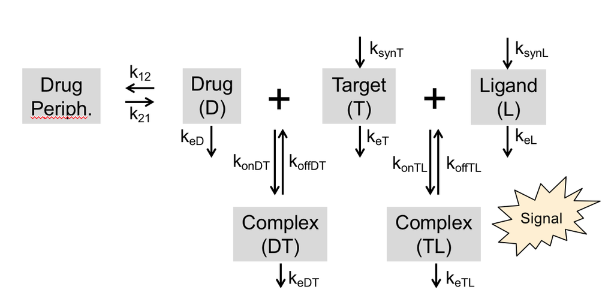

The equations for the model are:

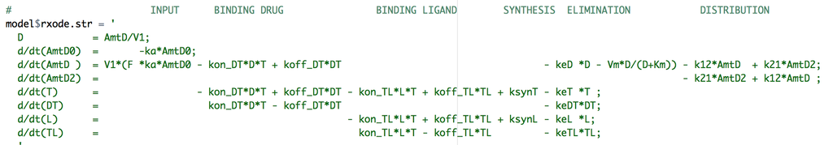

The model parameters used for some initial simulations, based loosely on Tocilizumab (drug), soluble IL-6R (target) and IL-6 (ligand) kinetics. The parameters are provided below.

```r
# Load model and parameters.
source("ivsc_2cmt_DTL.R")
model           = ivsc_2cmt_DTL()
drugs           = "Tocilizumab"
filename        = paste0("../data/ModelG_", drugs,"_Params.xlsx")
param = read.param.file(filename)
df_param        = as.data.frame(t(param))

d = read_excel(filename) %>%
  select(-Order) %>%
  mutate(Value = signif(Value,2))
kable(d)
```

| ParamType | Molecule | Description | Parameter | Value | Units | Source | Formula | Comment or Reference |
| --- | --- | --- | --- | --- | --- | --- | --- | --- |
| PK | Drug | Bioavailabiity | F | 0.000 | - | set to 0 not used | NA | NA |
| PK | Drug | Subcut. Absorption | ka | 0.000 | 1/d | set to 0 not used | NA | NA |
| PK | Drug | Clearance | CL | 0.290 | L/d | literature | NA | Gibiansky12 - Table 1 doi 10.1007/s10928-011-9227-z |
| PK | Drug | Central Volume | V1 | 3.700 | L | literature | NA | Gibiansky12 - Table 1 doi 10.1007/s10928-011-9227-z |
| PK | Drug | Intercomp. CL | Q | 0.200 | L/d | literature | NA | Gibiansky12 - Table 1 doi 10.1007/s10928-011-9227-z |
| PK | Drug | Periph. Volume | V2 | 3.400 | L | literature | NA | Gibiansky12 - Table 1 doi 10.1007/s10928-011-9227-z |
| PK | Drug | Elimination Rate | keD | 0.078 | 1/d | calc | =CL_/V1_ | NA |
| PK | Drug | Cental–>Periph Transit | k12 | 0.054 | NA | calc | =Q_/V1_ | NA |
| PK | Drug | Periph–>Central Transit | k21 | 0.059 | NA | calc | =Q_/V2_ | NA |
| PK | Drug | Nonlinear Elim Vmax | Vm_ugml | 1.400 | ug/(ml*d) | literature | NA | Gibiansky12 - Table 1 doi 10.1007/s10928-011-9227-z |
| PK | Drug | Nonlinear Elim Km | Km_ugml | 0.370 | ug/ml | literature | NA | Gibiansky12 - Table 1 doi 10.1007/s10928-011-9227-z |
| PK | Drug | Nonlinear Elim Vmax | Vm | 9.500 | nM/d | calc | =Vm*1000/MWD | NA |
| PK | Drug | Nonlinear Elim Km | Km | 2.500 | nM | calc | =Km*1000/MWD | NA |
| Binding | Drug | Molecular Weight | MWD | 150.000 | kDa | literature | NA | Gibiansky12 - doi 10.1007/s10928-011-9227-z |
| Binding | Soluble Target | Molecular Weight | MWT | 52.000 | kDa | literature | NA | google search |
| Binding | Soluble Ligand | Molecular Weight | MWL | 21.000 | kDa | literature | NA | google search |
| Turnover | Soluble Target | Synthesis Rate | ksyn_ngml | 48.000 | ng/(ml*d) | literature | NA | Gibiansky12 - Table 2 doi 10.1007/s10928-011-9227-z |
| Turnover | Soluble Target | Synthesis Rate | ksynT | 0.920 | nM/d | calc | =ksyn_ngml/MWTs | NA |
| Turnover | Soluble Target | Elimination Rate | keT | 1.300 | 1/d | literature | NA | Gibiansky12 - Table 2 doi 10.1007/s10928-011-9227-z |
| Turnover | Soluble Target | “Inhibition” | Imax | 0.940 | - | literature | NA | Gibiansky12 - Table 2 doi 10.1007/s10928-011-9227-z |
| Turnover | Soluble Target | Elimination Rate | keDT | 0.077 | 1/d | calc | =(1-Imax)*keTs | NA |
| Turnover | Soluble Target | Baseline Levels | T0 | 0.730 | nM | calc | =ksynTs/keTs | NA |
| Binding | Soluble Target | Bindinig Affinity | Kd_ugml | 0.180 | ug/ml | literature | NA | Gibiansky12 - Table 2 doi 10.1007/s10928-011-9227-z |
| Binding | Soluble Target | Bindinig Affinity | Kd_DT | 3.500 | nM | calc | =kd_ugml/MWTs*1000 | NA |
| Binding | Soluble Target | Disassociation Rate | koff_DT | 5.000 | 1/d | guess | NA | typical value (1-100) from Yang16 Fig 12 - dx.doi.org/10.1016/j.ab.2016.06.024 |
| Binding | Soluble Target | Association Rate | kon_DT | 1.400 | 1/(nM*d) | calc | =koff_DT/Kd_DT | NA |
| Turnover | Soluble Ligand | Synthesis Rate | ksynL | 0.080 | nM/d | calc | =L0*keL | Stein17 - Table 1 doi:10.1002/psp4.12169 |
| Turnover | Soluble Ligand | Elimination Rate | keL | 40.000 | 1/d | literature | NA | Stein17 - Table 1 doi:10.1002/psp4.12169 |
| Turnover | Soluble Ligand | Elimination Rate | keTL | 1.300 | 1/d | guess | =keT | WILL NEED TO BE TUNED TO CHAROIN DATA |
| Turnover | Soluble Ligand | Baseline Levels | L0 | 0.002 | nM | literature | =0.002 | Match patient from Charoin10 |
| Binding | Soluble Ligand | Bindinig Affinity | Kd_TL | 1.000 | nM | literature | NA | Ward96 - doi: 10.1074/jbc.271.33.20138 |
| Binding | Soluble Ligand | Disassociation Rate | koff_TL | 5.000 | 1/d | guess | NA | typical value (1-100) from Yang16 Fig 12 - dx.doi.org/10.1016/j.ab.2016.06.024 |
| Binding | Soluble Ligand | Association Rate | kon_TL | 5.000 | 1/(nM*d) | calc | =koff_TL/Kd_TL | NA |

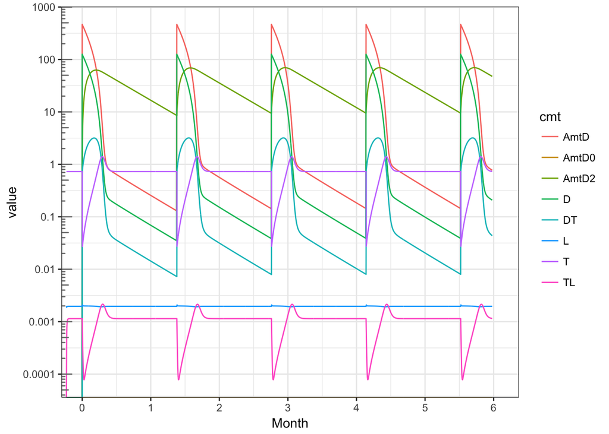

```r
#Set dosing parameters
dose.nmol       = scale.mpk2nmol #1 mg/kg (mpk)
tmax            = 26*7 #days (maximum time point)
tau             = 42   #days between doses
compartment     = 2    #compartment drug is dosed into

#set sampling and dosing event (ev) table
ev = eventTable(amount.units="nmol", time.units="days")
sample.points = c(seq(-7, tmax, 0.1), 10^(-3:0)) # sample time, increment by 0.1
sample.points = sort(sample.points)
sample.points = unique(sample.points)
ev$add.sampling(sample.points)
ev$add.dosing(dose            = dose.nmol,
              nbr.doses       = floor(tmax/tau)+1,
              dosing.interval = tau,
              dosing.to       = compartment)

#set the initial condition
init = model$init(param)

#run the model
out  = model$rxode$solve(param, ev, init)
out  = model$rxout(out)

#modify output dataframe for plotting
out.plot = out %>%
  select(-Ttot,-Ltot) %>%
  gather(cmt,value,-c(time))

#plot the results
  g = ggplot(out.plot,aes(x=time,y=value,group=cmt,color=cmt))
  g = g + geom_line()
  g = g + scale.y.log10()
  g = g + scale_x_units(units.input = "day",units.output = "month",increment = 1,t.end = tmax/30)
  print(g)
```

# Simulation of a single dose, overlaying data from Tocilizumab - Model G (DTL)

Below, data is taken from the following reference

- Jean-Eric Charoin, Micha Levi, Nicolas Frey, Isabelle Delor, and Philippe Jacqmin. Target mediated drug disposition (tmdd) in rheumatoid arthritis, a case study using tocilizumab. Presenetd at the 6th International Symposium on Measurement and Kinetics of in Vivo Drug Effects in Noordwijkerhout, The Netherlands, 2010.

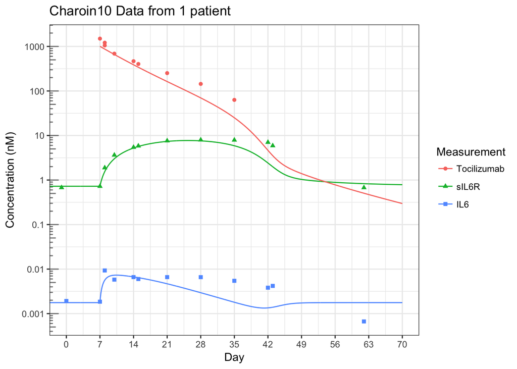

```r
d = read_csv("../data/Charoin10_RA_1pt/Task01_Charoin10_Data_1pat.csv") %>%
  filter(VALNAME != "CRP") %>%
  arrange(-VALUE) %>%
  mutate(VALNAME = factor(VALNAME,levels=unique(VALNAME)))

g = ggplot(data=d,aes(x=TIME,y=VALUE,color=VALNAME,shape=VALNAME))
g = g + geom_point()
#g = g + geom_line()
g = g + scale.y.log10()
g = g + scale_x_units(t.end = max(d$TIME))
g = g + labs(y="Concentration (nM)",
             color = "Measurement",
             shape = "Measurement")
g = g + ggtitle("Charoin10 Data from 1 patient")
gdata = g

#set up dosing
ev = eventTable(amount.units="nmol", time.units="days")
ev$add.sampling(seq(-7,70,by = .1))
ev$add.dosing(dose            = 8*scale.mpk2nmol,
              nbr.doses       = 1,
              start.time      = 7,
              dosing.to       = compartment)

#tweak param
param["ksynL"] =.008
param["keL"] =  1
param["keTL"] = 200

#set initial condition
init = model$init(param)

#run the model
out  = model$rxode$solve(param, ev, init)
out  = model$rxout(out) %>%
  select(TIME=time,
         Tocilizumab = D,
         sIL6R = Ttot,
         IL6 = L) %>%
  gather(VALNAME,VALUE,-TIME) %>%
  mutate(VALUE = ifelse(VALUE==0,NA,VALUE))

  g = gdata + geom_line(data=out)
  g = g + scale_x_units(t.end = max(out$TIME))
  print(g)
```

```r
  ggsave("../results/Task04_Toci_Sim_Data.png",width=4,height=4)
```

# Trying a second model with membrane-bound target (mIL6R) - Model H (DT2L)

The model below is simulated with a membrane-bound target as well

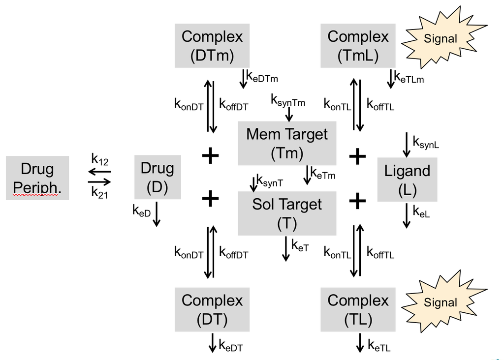

The equations for the model are:

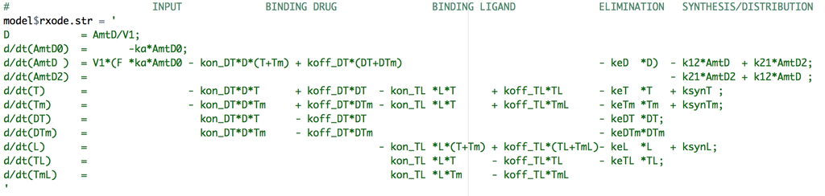

```r
model           = ivsc_2cmt_DT2L()
drugs           = "Tocilizumab"
filename        = paste0("../data/ModelH_", drugs,"_Params.xlsx")
param = read.param.file(filename)
d.param        = as.data.frame(t(param))

d = read_excel(filename) %>%
  select(-Order) %>%
  mutate(Value = signif(Value,2))
kable(d)
```

[output not shown]

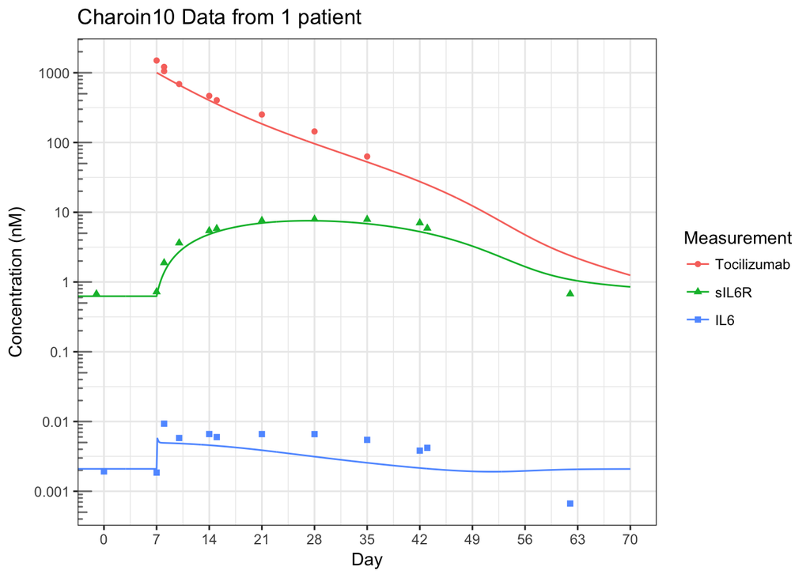

```r
init = model$init(param)

out  = model$rxode$solve(param, ev, init)
out  = model$rxout(out) %>%
  select(TIME=time,
         Tocilizumab = D,
         sIL6R = Ttot,
         IL6 = L) %>%
  gather(VALNAME,VALUE,-TIME) %>%
  mutate(VALUE = ifelse(VALUE<1e-6,NA,VALUE))

  g = gdata + geom_line(data=out)
  g = g + scale_x_units(t.end = max(out$TIME))
  print(g)
```

```r
  ggsave("../results/Task04_Toci_Sim_Data_Tm.png",width=4,height=4)
```